# Day 2: TheoryTag 2: Theorie

Spatial Algorithms & Research DesignRäumliche Algorithmen & Forschungsdesign

Ecology WorkshopÖkologie-Workshop

2026-01-28

# Review & Research QuestionWiederholung & Forschungsfrage

## Quick Review from Day 1Kurze Wiederholung von Tag 1

Yesterday we learned:

- **Biodiversity** = variety of species in an area
- **Accumulation curves** show how species discovery slows with sampling effort
- **Asymptote** = estimated total species (what we’re approaching)
- Austrian data has **native** (natural) and **alien** (introduced) species

Gestern haben wir gelernt:

- **Biodiversität** = Artenvielfalt in einem Gebiet
- **Akkumulationskurven** zeigen, wie die Artenentdeckung mit dem Stichprobenaufwand abnimmt
- **Asymptote** = geschätzte Gesamtartenzahl (was wir anstreben)
- Österreichische Daten haben **heimische** (natürliche) und **Alien**- (eingeführte) Arten

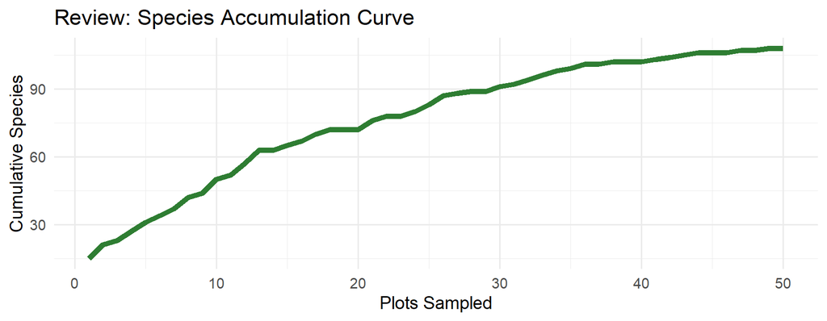

## Today’s Research QuestionHeutige Forschungsfrage

**Do alien species accumulate differently than native species?**

**Hypotheses:**

- **H1:** Alien species accumulate **more slowly** (fewer species overall)
- **H2:** Alien species show **different spatial patterns** than natives
- **H3:** The curves will have **different shapes**

**Akkumulieren Alien-Arten anders als heimische Arten?**

**Hypothesen:**

- **H1:** Alien-Arten akkumulieren **langsamer** (weniger Arten insgesamt)
- **H2:** Alien-Arten zeigen **andere räumliche Muster** als Einheimische
- **H3:** Die Kurven werden **unterschiedliche Formen** haben

## Why Use Spatial Accumulation Curves?Warum räumliche Akkumulationskurven verwenden?

**The key question:** Why not just count species? Why do we need accumulation curves?

**Answer:** Accumulation curves reveal **where** species are, not just **how many**.

**Die Schlüsselfrage:** Warum nicht einfach Arten zählen? Warum brauchen wir Akkumulationskurven?

**Antwort:** Akkumulationskurven zeigen **wo** Arten sind, nicht nur **wie viele**.

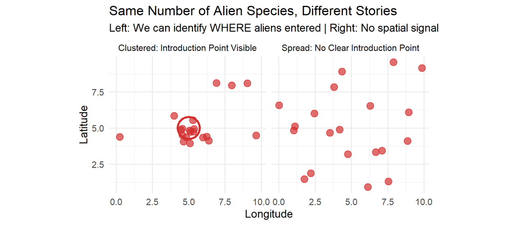

**Why this matters for invasion biology:**

| What we learn | How it helps |
| --- | --- |
| **Introduction points** | Where did aliens first arrive? (ports, cities, gardens) |
| **Spread patterns** | How are they dispersing across the landscape? |
| **Invasion hotspots** | Which areas have the most alien species? |
| **Management priorities** | Where should we focus control efforts? |

**The curve shape tells the story:** If aliens accumulate slowly at first then speed up, they’re clustered around introduction points. If they accumulate steadily, they’ve already spread everywhere.

**Warum das für Invasionsbiologie wichtig ist:**

| Was wir lernen | Wie es hilft |
| --- | --- |
| **Einführungspunkte** | Wo kamen Aliens zuerst an? (Häfen, Städte, Gärten) |
| **Ausbreitungsmuster** | Wie verbreiten sie sich über die Landschaft? |
| **Invasions-Hotspots** | Welche Gebiete haben die meisten Alien-Arten? |
| **Management-Prioritäten** | Wo sollten wir Kontrollmaßnahmen fokussieren? |

**Die Kurvenform erzählt die Geschichte:** Wenn Aliens anfangs langsam akkumulieren und dann schneller werden, sind sie um Einführungspunkte geclustert. Wenn sie gleichmäßig akkumulieren, haben sie sich bereits überall verbreitet.

## Hotspot Maps: Austria ExampleHotspot-Karten: Österreich-Beispiel

What might hotspot maps look like for Austria? Here’s a hypothetical example showing how alien and native species might be distributed differently across the landscape.

Wie könnten Hotspot-Karten für Österreich aussehen? Hier ist ein hypothetisches Beispiel, das zeigt, wie Alien- und heimische Arten unterschiedlich über die Landschaft verteilt sein könnten.

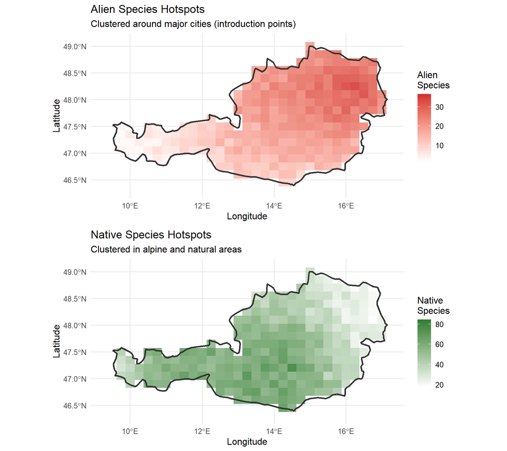

**Key observations (hypothetical):**

- **Alien species** concentrate around **Vienna, Linz, Salzburg** - major cities with ports, railways, and gardens where species are introduced
- **Native species** concentrate in **alpine regions** - natural habitats with high endemic diversity
- The **patterns are almost opposite** - this is what accumulation curves can reveal!

**Wichtige Beobachtungen (hypothetisch):**

- **Alien-Arten** konzentrieren sich um **Wien, Linz, Salzburg** - Großstädte mit Häfen, Eisenbahnen und Gärten, wo Arten eingeführt werden
- **Heimische Arten** konzentrieren sich in **alpinen Regionen** - natürliche Lebensräume mit hoher endemischer Vielfalt
- Die **Muster sind fast gegensätzlich** - das können Akkumulationskurven aufdecken!

# The Spatial AlgorithmDer räumliche Algorithmus

## Why Does Order Matter?Warum ist die Reihenfolge wichtig?

Yesterday we built curves by sampling plots in **random order**.

But in real ecology, we often care about **spatial patterns**:

- Do species cluster geographically?
- How does diversity change as we move across a landscape?

**Solution:** Sample plots in **spatial order** - always go to the nearest unvisited plot!

Gestern haben wir Kurven erstellt, indem wir Plots in **zufälliger Reihenfolge** untersucht haben.

Aber in der realen Ökologie interessieren uns oft **räumliche Muster**:

- Sind Arten geografisch geclustert?
- Wie verändert sich die Diversität über eine Landschaft?

**Lösung:** Plots in **räumlicher Reihenfolge** untersuchen - immer zum nächsten unbesuchten Plot gehen!

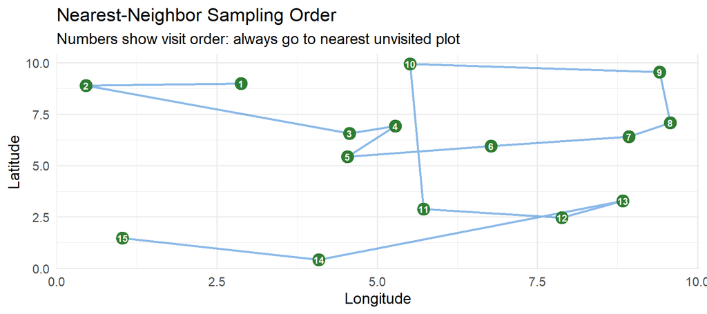

## The Nearest-Neighbor AlgorithmDer Nearest-Neighbor-Algorithmus

**Step by step:**

1. Pick a **starting plot** (seed)
2. Mark it as **visited**
3. Find the **nearest unvisited** plot
4. Move there, record new species, mark as visited
5. **Repeat** until all plots are visited

**Schritt für Schritt:**

1. Wähle einen **Startplot** (Seed)
2. Markiere ihn als **besucht**
3. Finde den **nächsten unbesuchten** Plot
4. Gehe dorthin, notiere neue Arten, markiere als besucht
5. **Wiederhole** bis alle Plots besucht sind

## The Distance FormulaDie Entfernungsformel

Distance between two points (x1, y1) and (x2, y2):

$$d = \sqrt{(x_2 - x_1)^2 + (y_2 -
y_1)^2}$$

This is the **Euclidean distance** - the straight-line distance between two points.

Entfernung zwischen zwei Punkten (x1, y1) und (x2, y2):

$$d = \sqrt{(x_2 - x_1)^2 + (y_2 -
y_1)^2}$$

Dies ist die **Euklidische Distanz** - die Luftlinie zwischen zwei Punkten.

# Multiple Starting PointsMehrere Startpunkte

## Why Multiple Seeds?Warum mehrere Seeds?

The shape of the curve depends on **where we start**!

- Starting in a species-rich area: fast initial accumulation
- Starting in a species-poor area: slow initial accumulation

**Solution:** Run the algorithm multiple times with different starting points, then average.

Die Form der Kurve hängt davon ab, **wo wir starten**!

- Start in artenreichem Gebiet: schnelle anfängliche Akkumulation
- Start in artenarmem Gebiet: langsame anfängliche Akkumulation

**Lösung:** Den Algorithmus mehrmals mit verschiedenen Startpunkten ausführen, dann mitteln.

## Visualizing Starting PositionsStartpositionen visualisieren

Let’s imagine we have plots spread across a landscape. Some areas are **biodiversity hotspots** (many species), others are **low-diversity areas** (few species).

Where we choose to start our sampling walk dramatically affects the curve shape!

Stellen wir uns vor, wir haben Plots über eine Landschaft verteilt. Einige Gebiete sind **Biodiversitäts-Hotspots** (viele Arten), andere sind **artenarme Gebiete** (wenige Arten).

Wo wir unseren Probenweg beginnen, beeinflusst die Kurvenform dramatisch!

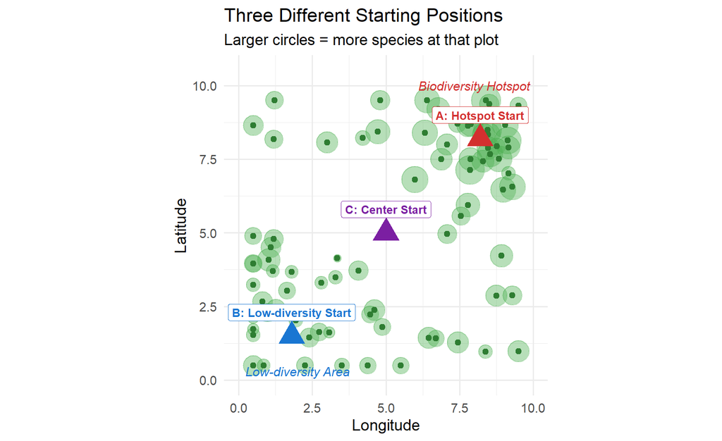

**What happens with each start?**

| Start Position | Initial Species | Curve Shape |
| --- | --- | --- |
| **A: Hotspot** | Many species quickly | Steep rise, then flattens |
| **B: Low-diversity** | Few species slowly | Gradual rise throughout |
| **C: Center** | Medium start | Balanced curve |

**Was passiert bei jedem Start?**

| Startposition | Anfängliche Arten | Kurvenform |
| --- | --- | --- |
| **A: Hotspot** | Viele Arten schnell | Steiler Anstieg, dann flach |
| **B: Artenarm** | Wenige Arten langsam | Gradueller Anstieg |
| **C: Zentrum** | Mittlerer Start | Ausgewogene Kurve |

## The Effect of Starting PositionDer Effekt der Startposition

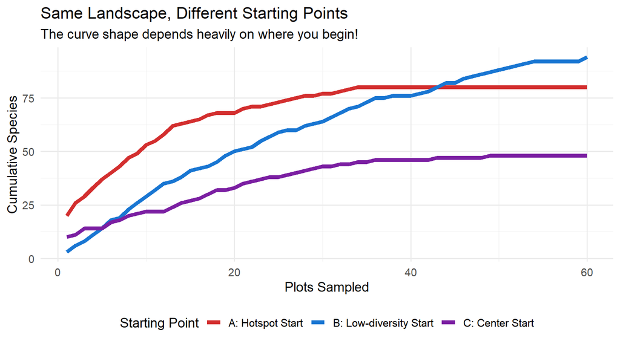

This is why we must consider multiple starting points in our analysis.

Deshalb müssen wir mehrere Startpunkte in unserer Analyse berücksichtigen.

# The Null HypothesisDie Nullhypothese

## What If Starting Position Doesn’t Matter?Was wenn die Startposition egal ist?

**The Null Hypothesis (H₀):**

> “Starting position does not affect the accumulation curve - all curves from different starting points should look the same.”

**If true:** Species are randomly distributed across the landscape. No hotspots, no clusters. Every location is equally likely to have any species.

**Die Nullhypothese (H₀):**

> “Die Startposition beeinflusst die Akkumulationskurve nicht - alle Kurven von verschiedenen Startpunkten sollten gleich aussehen.”

**Wenn wahr:** Arten sind zufällig über die Landschaft verteilt. Keine Hotspots, keine Cluster. Jeder Ort hat die gleiche Wahrscheinlichkeit für jede Art.

[figure not shown]

## Testing the Null HypothesisTesten der Nullhypothese

**How we test this:**

1. Run the sampling algorithm from **many different starting points** (e.g., 20 seeds)
2. Compare the curves - do they overlap or diverge?
3. Calculate the **variation between curves**

**If H₀ is true:** All curves should be nearly identical (low variation)

**If H₀ is false:** Curves should differ based on starting location (high variation)

**Wie wir das testen:**

1. Den Sampling-Algorithmus von **vielen verschiedenen Startpunkten** ausführen (z.B. 20 Seeds)
2. Die Kurven vergleichen - überlappen sie oder divergieren sie?
3. Die **Variation zwischen Kurven** berechnen

**Wenn H₀ wahr ist:** Alle Kurven sollten fast identisch sein (geringe Variation)

**Wenn H₀ falsch ist:** Kurven sollten je nach Startort variieren (hohe Variation)

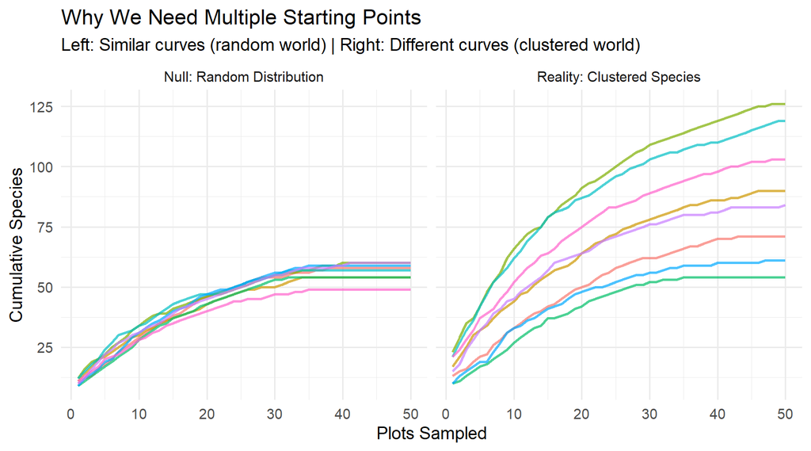

**Key Insight:**

In a world where species are **randomly distributed** (H₀), all curves look similar regardless of starting point.

In the **real world** where species cluster around favorable habitats, curves differ dramatically based on where you start.

**This is why we average across multiple seeds!** It gives us a more representative picture of the overall biodiversity pattern.

**Wichtige Erkenntnis:**

In einer Welt, in der Arten **zufällig verteilt** sind (H₀), sehen alle Kurven ähnlich aus, unabhängig vom Startpunkt.

In der **realen Welt**, wo Arten sich um günstige Habitate clustern, unterscheiden sich die Kurven dramatisch je nach Startort.

**Deshalb mitteln wir über mehrere Seeds!** Das gibt uns ein repräsentativeres Bild des gesamten Biodiversitätsmusters.

## What Does High Variation Tell Us?Was sagt uns hohe Variation?

When curves from different starting points **vary a lot**, it tells us:

1. **Species are clustered** - not evenly spread across the landscape
2. **Hotspots exist** - some areas are biodiversity-rich
3. **Geography matters** - position affects what you find

This is actually **more interesting** than finding uniform curves! It means there are spatial patterns worth investigating.

Wenn Kurven von verschiedenen Startpunkten **stark variieren**, sagt uns das:

1. **Arten sind geclustert** - nicht gleichmäßig über die Landschaft verteilt
2. **Hotspots existieren** - einige Gebiete sind biodiversitätsreich
3. **Geografie ist wichtig** - Position beeinflusst, was man findet

Das ist eigentlich **interessanter** als einheitliche Kurven zu finden! Es bedeutet, dass es räumliche Muster gibt, die es wert sind, untersucht zu werden.

# Comparing Native vs. AlienVergleich Heimisch vs. Alien

## Our Research HypothesisUnsere Forschungshypothese

**Research Question:** Do alien (introduced) species accumulate differently than native species across the Austrian landscape?

**Null Hypothesis (H₀):** > Native and alien species accumulate at the same rate - their curves have the same shape. There is no difference in spatial distribution patterns.

**Alternative Hypothesis (H₁):** > Native and alien species have different accumulation patterns, reflecting differences in how they are distributed across the landscape.

**Forschungsfrage:** Akkumulieren Alien-Arten (eingeführte Arten) anders als heimische Arten über die österreichische Landschaft?

**Nullhypothese (H₀):** > Heimische und Alien-Arten akkumulieren mit der gleichen Rate - ihre Kurven haben die gleiche Form. Es gibt keinen Unterschied in den räumlichen Verteilungsmustern.

**Alternativhypothese (H₁):** > Heimische und Alien-Arten haben unterschiedliche Akkumulationsmuster, die Unterschiede in ihrer Verteilung über die Landschaft widerspiegeln.

**What might we expect?**

| Hypothesis | Prediction | Biological Reasoning |
| --- | --- | --- |
| **Aliens accumulate faster** | Steeper initial curve | Aliens are generalists, found everywhere |
| **Aliens accumulate slower** | Flatter initial curve | Aliens are clustered near introduction points (cities, ports) |
| **No difference** | Identical curves | Distribution patterns are similar |

**The key insight:** By comparing normalized curves, we can see if one group is more clustered or more evenly spread than the other.

**Was könnten wir erwarten?**

| Hypothese | Vorhersage | Biologische Begründung |
| --- | --- | --- |
| **Aliens akkumulieren schneller** | Steilere anfängliche Kurve | Aliens sind Generalisten, überall zu finden |
| **Aliens akkumulieren langsamer** | Flachere anfängliche Kurve | Aliens sind geclustert nahe Einführungspunkten (Städte, Häfen) |
| **Kein Unterschied** | Identische Kurven | Verteilungsmuster sind ähnlich |

**Die wichtige Erkenntnis:** Durch den Vergleich normalisierter Kurven können wir sehen, ob eine Gruppe stärker geclustert oder gleichmäßiger verteilt ist als die andere.

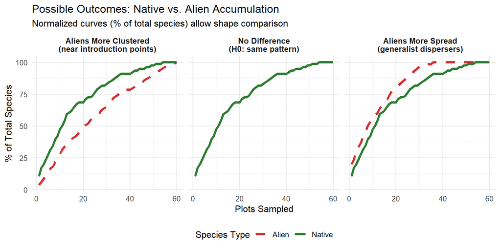

## Normalization for Fair ComparisonNormalisierung für fairen Vergleich

The raw curves are hard to compare because there are many more native species.

**Solution:** Normalize to percentage of total species found.

This lets us compare the **shape** of accumulation, not just the total numbers.

Die Rohkurven sind schwer zu vergleichen, weil es viel mehr heimische Arten gibt.

**Lösung:** Auf Prozent der gefundenen Gesamtarten normalisieren.

So können wir die **Form** der Akkumulation vergleichen, nicht nur die Gesamtzahlen.

# Interpretation & DiscussionInterpretation & Diskussion

## Discussion QuestionsDiskussionsfragen

1. **Why might alien species be more evenly distributed?**
   - Human-mediated dispersal (trade, transport)
   - Generalist habitat preferences
   - Recent introduction = no time to cluster
2. **What are the limitations of our analysis?**
   - Geographic bias in sampling (some regions better covered)
   - Detection probability differs by species
   - Single time snapshot (no temporal dynamics)
3. **What could be explored further?**
   - Compare different habitat types (forests vs. grasslands)
   - Look at temporal changes (are aliens spreading?)
   - Test in other countries
1. **Warum könnten Alien-Arten gleichmäßiger verteilt sein?**
   - Vom Menschen vermittelte Ausbreitung (Handel, Transport)
   - Generalistische Habitatpräferenzen
   - Kürzliche Einführung = keine Zeit zum Clustern
2. **Was sind die Einschränkungen unserer Analyse?**
   - Geografische Verzerrung (manche Regionen besser beprobt)
   - Nachweiswahrscheinlichkeit unterscheidet sich zwischen Arten
   - Einzelne Zeitmomentaufnahme (keine zeitliche Dynamik)
3. **Was könnte weiter untersucht werden?**
   - Verschiedene Habitattypen vergleichen (Wald vs. Wiese)
   - Zeitliche Veränderungen (breiten sich Aliens aus?)
   - In anderen Ländern testen

## Biological MechanismsBiologische Mechanismen

**Why do accumulation patterns differ?**

| Factor | Effect on Curve Shape |
| --- | --- |
| **Dispersal ability** | Good dispersers = even distribution = gradual curve |
| **Habitat specificity** | Specialists = clustered = steep then flat |
| **Historical range** | Long history = natural clustering patterns |
| **Human influence** | Transport along roads, rivers = linear patterns |

**Warum unterscheiden sich Akkumulationsmuster?**

| Faktor | Effekt auf Kurvenform |
| --- | --- |
| **Ausbreitungsfähigkeit** | Gute Ausbreiter = gleichmäßige Verteilung = graduelle Kurve |
| **Habitatspezifität** | Spezialisten = geclustert = steil dann flach |
| **Historische Verbreitung** | Lange Geschichte = natürliche Clustermuster |
| **Menschlicher Einfluss** | Transport entlang Straßen, Flüssen = lineare Muster |

# Future DirectionsZukünftige Richtungen

## Beyond Species Richness: Biomass AccumulationÜber Artenreichtum hinaus: Biomasse-Akkumulation

So far we’ve only counted **species** (species richness). But what about **how much** of each species is present?

**Biomass accumulation curves** could tell us even more:

| Metric | What it measures | What it reveals |
| --- | --- | --- |
| **Species richness** | Number of different species | Diversity patterns |
| **Biomass** | Total weight/cover of plants | Dominance patterns |
| **Combined** | Both together | Full ecological picture |

Bisher haben wir nur **Arten** gezählt (Artenreichtum). Aber was ist mit **wie viel** von jeder Art vorhanden ist?

**Biomasse-Akkumulationskurven** könnten uns noch mehr verraten:

| Metrik | Was sie misst | Was sie zeigt |
| --- | --- | --- |
| **Artenreichtum** | Anzahl verschiedener Arten | Diversitätsmuster |
| **Biomasse** | Gesamtgewicht/-deckung der Pflanzen | Dominanzmuster |
| **Kombiniert** | Beides zusammen | Vollständiges ökologisches Bild |

[figure not shown]

**Why biomass matters:**

- A few **dominant species** might contribute most of the biomass
- Alien species could have **high biomass but low diversity** (invasive monocultures)
- Native ecosystems might show **balanced biomass across many species**

**Research question:** Do alien species contribute disproportionately to biomass relative to their species count?

**Warum Biomasse wichtig ist:**

- Einige wenige **dominante Arten** könnten den Großteil der Biomasse ausmachen
- Alien-Arten könnten **hohe Biomasse aber geringe Diversität** haben (invasive Monokulturen)
- Heimische Ökosysteme könnten **ausgewogene Biomasse über viele Arten** zeigen

**Forschungsfrage:** Tragen Alien-Arten überproportional zur Biomasse bei im Verhältnis zu ihrer Artenzahl?

# SummaryZusammenfassung

## Key ConceptsSchlüsselkonzepte

| Concept | What we learned |
| --- | --- |
| **Spatial order** | The sequence we visit plots affects the curve shape |
| **Nearest-neighbor** | Algorithm: always go to closest unvisited plot |
| **Multiple seeds** | Different starting points = different curves = need to average |
| **Native vs. Alien** | Different accumulation patterns reveal ecological differences |

| Konzept | Was wir gelernt haben |
| --- | --- |
| **Räumliche Reihenfolge** | Die Reihenfolge, in der wir Plots besuchen, beeinflusst die Kurvenform |
| **Nearest-Neighbor** | Algorithmus: immer zum nächsten unbesuchten Plot gehen |
| **Mehrere Seeds** | Verschiedene Startpunkte = verschiedene Kurven = Mittelung nötig |
| **Heimisch vs. Alien** | Unterschiedliche Akkumulationsmuster zeigen ökologische Unterschiede |

## Take-Home MessageFazit

> Accumulation curves reveal how species are distributed across space. Comparing native and alien species shows us which group is more clustered and helps identify invasion hotspots.

> Akkumulationskurven zeigen, wie Arten im Raum verteilt sind. Der Vergleich von heimischen und Alien-Arten zeigt uns, welche Gruppe stärker geclustert ist, und hilft Invasions-Hotspots zu identifizieren.